← Back to index

# Cell Analysis Pipeline

Analysis of time-lapse phase-contrast image stacks of round cells/bacteria.

| Step | Section | Description |
| --- | --- | --- |
| 1 | Load image stacks | Load paired phase-contrast and fluorescence TIFF stacks |
| 2 | Detect cells in frame 0 | Cellpose segmentation with area, circularity, contrast filters |
| 3 | Visualize detections | Overlay detected centroids on frame 0 (full + zoom) |
| 4 | Detect across all frames | Run Cellpose on every frame of the time-lapse stack |
| 4.1 | Frame quality gating | Flag anomalous frames via MAD-based Z-scores |
| 5 | Track cells over time | Link detections into tracks with trackpy + merge fragments |
| 5.1 | Minimum-lifetime filter | Remove ultra-short tracks (likely debris) |
| 6 | Statistics and plots | Morphology and dynamics analysis |
| 6.1 | Cell count per frame | Tracked cell count over time |
| 6.2 | Lifetime distribution | Track duration histogram and disappearance classification |
| 6.3 | Cell area distribution | Area histogram pooled over the first `BASELINE_FRAMES` frames; areas in µm² via `PIXEL_SIZE_UM` |
| 6.4 | Swelling dynamics | Population-averaged V(t)/V(0) and S(t)/S(0) curves |
| 6.5 | Swelling vs. survival | Max swelling by V(0) in µm³; died vs. survived curves |
| 6.5b | Swelling vs normalized lifespan | V(t)/V(0) three-panel: per-frame, lifespan-normalized by fate, frame-axis by fate |
| 7 | Fluorescence preview | Side-by-side phase-contrast and fluorescence overview |
| 8 | Fluorescence quantification | Per-cell fluorescence metrics within phase masks |
| 8.1 | Mean fluorescence per frame | Population mean and median intensity over time |
| 8.2 | Relative fluorescence | F(t)/F(0) curves, split by cell fate |
| 8.2b | Fluorescence vs normalized lifespan | F(t)/F(0) three-panel companion to §6.5b |
| 8.3 | Fluorescence vs. swelling | Scatter of intensity vs. volume per cell-frame |
| 8.4 | CV dynamics | Nucleoid spatial concentration over time (split by fate) |
| 8.4c | Nucleoid edge-distance dynamics | Suprathreshold-pixel mean edge-distance / (R/3), three-panel by fate |
| 8.5 | nNRM dynamics | Non-normality of pixel distributions over time (split by fate) |
| 8.5b | Nucleoid σ dynamics | Intensity-weighted σ / R, three-panel by fate |
| 8.6 | Fluorescence dynamics around phase disappearance | ±window-frame alignment of F(t) to phase mask loss |
| 8.9 | Fluorescence concentration | Dilution-corrected intensity (total/volume) |
| 8.11 | SA:V ratio | Surface-area-to-volume as membrane stress proxy |
| 8.13 | Pre-burst fluorescence | Fluorescence trend in frames before lysis |
| 8.14 | Fate prediction | Mann-Whitney U on area/CV/nNRM/edge-dist/σ + logistic regression (LOO-CV) on the frame-0 cohort |
| 8.16 | Nucleus persistence | Phase vs. fluorescence object count correlation |
| 8.17 | Initial features vs. lifespan | Frame-0 Fl/CV/nNRM vs track lifetime scatter (Spearman) |
| 9 | Export results | Save all DataFrames and summaries to CSV |
| 10 | Export HTML report | Save self-contained HTML copy of this notebook (opt-in via `EXPORT_HTML`) |

## Configuration

All tunable parameters in one place. Change `RUN_NAME` for each experiment.

Run info

| Input | Path |
| --- | --- |
| Phase stack | `../data/Control-experiment/Grad LB+sucr-20-0.zvi Ch0.tif` |
| Fluorescence stack | `../data/Control-experiment/Grad LB+sucr-20-0.zvi Ch1-BG.tif` |

**Run name:** `Control-experiment`

| Detection parameter | Value |
| --- | --- |
| diameter | `32` |
| min_area | `300` |
| min_circularity | `0.7` |
| min_contrast | `1250` |
| exclude_edges | `True` |
| gpu | `True` |
| resample | `False` |
| model_type | `default` |

| Tracking / analysis parameter | Value |
| --- | --- |
| GATING_Z_THRESHOLD | `3.5` |
| SEARCH_RANGE | `30.0` |
| MEMORY | `3` |
| MERGE_MAX_DISTANCE | `15.0` |
| MERGE_MAX_GAP | `18` |
| PIXEL_SIZE_UM | `0.0645` |
| BASELINE_FRAMES | `3` |
| MIN_TRACK_DETECTIONS | `4` |
| FLUOR_ALIGN_WINDOW | `3` |
| Fate-prediction feature sets | full (5) vs no-area (4) |

```
Results will be saved to: results/control_experiment/
```

## 1. Load Image Stacks

```
Phase stack: (31, 1040, 1388) (frames=31, size=1388x1040, dtype=uint16)
Fluorescence stack: (31, 1040, 1388), dtype=uint16
```

### Preview: first frame

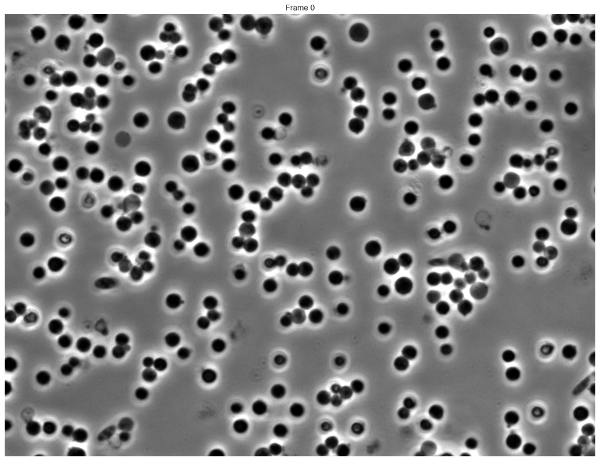

## 2. Detect Cells in Frame 0

Uses Cellpose (deep learning segmentation) with post-filters for area, circularity, contrast, and edge exclusion.

See docs/detection_tuning.md for parameter details.

```
Detected 240 cells in frame 0
```

## 3. Visualize: Frame 0 with detected cells

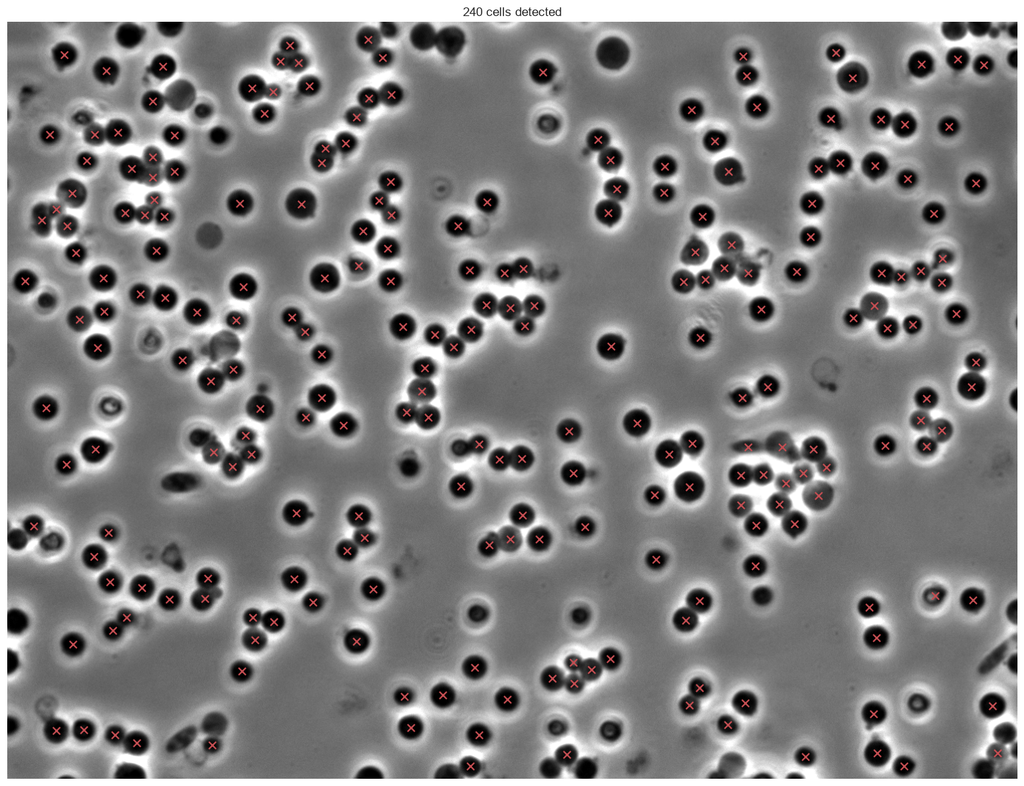

### Zoomed view (dense region)

Adjust the crop coordinates to inspect different parts of the image.

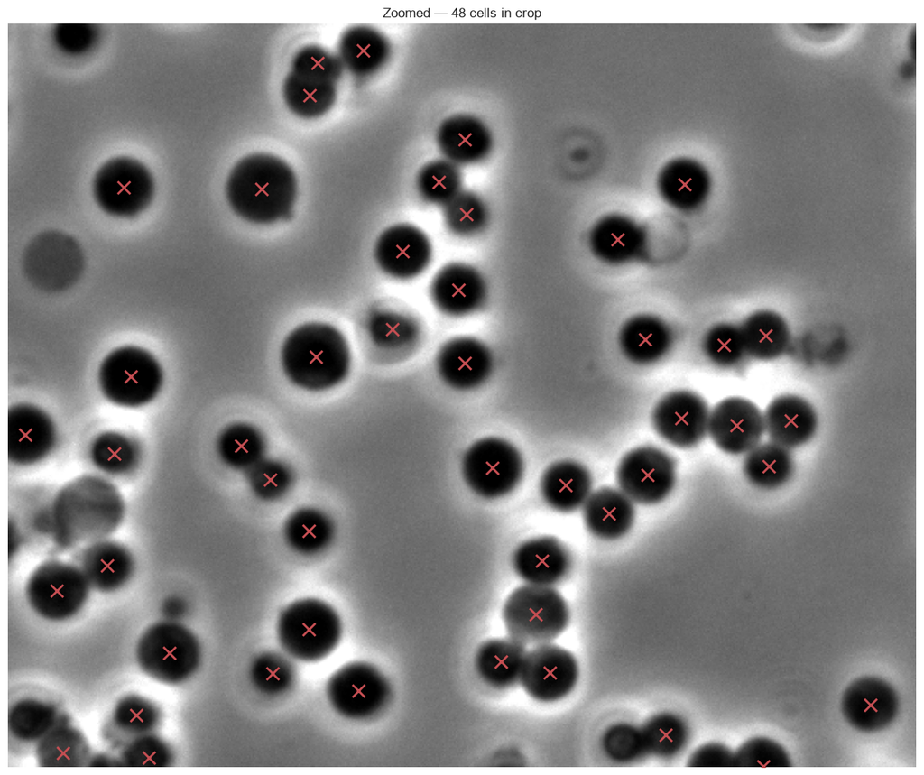

## 4. Detect Cells Across All Frames

*Runs Cellpose on each frame of the (possibly trimmed) stack. This takes several minutes on CPU.*

```
  Frame  0: 240 cells
```

```
  Frame  1: 240 cells
```

```
  Frame  2: 239 cells
```

```
  Frame  3: 241 cells
```

```
  Frame  4: 234 cells
```

```
  Frame  5: 239 cells
```

```
  Frame  6: 233 cells
```

```
  Frame  7: 229 cells
```

```
  Frame  8: 224 cells
```

```
  Frame  9: 225 cells
```

```
  Frame 10: 216 cells
```

```
  Frame 11: 214 cells
```

```
  Frame 12: 209 cells
```

```
  Frame 13: 200 cells
```

```
  Frame 14: 187 cells
```

```
  Frame 15: 174 cells
```

```
  Frame 16: 153 cells
```

```
  Frame 17: 151 cells
```

```
  Frame 18: 147 cells
```

```
  Frame 19: 135 cells
```

```
  Frame 20: 118 cells
```

```
  Frame 21: 106 cells
```

```
  Frame 22: 95 cells
```

```
  Frame 23: 85 cells
```

```
  Frame 24: 75 cells
```

```
  Frame 25: 77 cells
```

```
  Frame 26: 73 cells
```

```
  Frame 27: 67 cells
```

```
  Frame 28: 64 cells
```

```
  Frame 29: 61 cells
```

```
  Frame 30: 42 cells
```

### 4.1 Frame quality gating

Flags frames with anomalous detection statistics (out-of-focus, stage drift, illumination glitch) using MAD-based modified Z-scores on cell count, mean area, and area IQR. Flagged frames are excluded from tracking and fluorescence measurement.

```
Frame gating: no anomalous frames detected
No frames dropped — all frames passed quality gating.
```

[interactive chart not shown]

*Sources: `frame_diagnostics.csv`, `dropped_frames.csv`*

## 5. Track Cells Over Time

| Parameter | Description |
| --- | --- |
| `search_range` | Max pixels a cell can move between consecutive frames |
| `memory` | Frames a cell can vanish and still be re-linked |
| `max_distance` | Max pixels between track end/start to merge fragments |
| `max_gap` | Max frame gap for fragment merging |

```
Frame 30: 42 trajectories present.
Unique tracks (before merging): 284
Track merging: 284 → 271 tracks (13 merges, 13 fragments absorbed)
Unique tracks (after merging): 271
Cells that disappeared before last frame: 229

Merge log (13 merges):
```

|  | absorbed_track | into_track | distance | gap_frames | end_frame | start_frame |
| --- | --- | --- | --- | --- | --- | --- |
| 0 | 282 | 155 | 0.3 | 6 | 23 | 29 |
| 1 | 275 | 155 | 0.6 | 5 | 13 | 18 |
| 2 | 274 | 122 | 0.6 | 5 | 13 | 18 |
| 3 | 268 | 264 | 0.8 | 6 | 8 | 14 |
| 4 | 269 | 265 | 0.8 | 6 | 8 | 14 |
| 5 | 266 | 81 | 1.5 | 5 | 8 | 13 |
| 6 | 267 | 263 | 1.6 | 6 | 8 | 14 |
| 7 | 283 | 131 | 2.1 | 5 | 25 | 30 |
| 8 | 272 | 173 | 2.4 | 6 | 11 | 17 |
| 9 | 273 | 260 | 4.1 | 6 | 11 | 17 |
| 10 | 270 | 3 | 4.9 | 7 | 10 | 17 |
| 11 | 278 | 5 | 5.4 | 12 | 13 | 25 |
| 12 | 281 | 157 | 6.3 | 8 | 21 | 29 |

### 5.1 Minimum-lifetime filter

The filter below removes these before any downstream analysis. The threshold (`MIN_TRACK_DETECTIONS`) is set in the Configuration cell. Set it to 1 to disable.

```
Removed 20 tracks with <4 detections (19 were classified as disappeared)
Remaining: 251 tracks, 210 disappeared
```

## 6. Statistics and Plots

### 6.1 Cell count per frame

[interactive chart not shown]

```
Initial count (frame 0): 224
Final count (frame 30): 41
Fraction disappeared: 81.7%
50% disappearance frame: 21
```

*Source: `tracked_cells.csv`*

### 6.2 Lifetime distribution and disappearance

```
Total tracks: 251
Survived to final frame: 41 (16.3%)
Disappeared: 210 (83.7%)
Disappeared lifetime — median: 19, mean: 18.5 ± 6.7 frames
```

[interactive chart not shown]

```
Frame of maximum disappearance: 29
Cells lost at peak: 19
```

*Source: `track_statistics.csv`*

### 6.3 Cell area distribution

Histogram pooled over the first `BASELINE_FRAMES` frames (before medium changes drive swelling). Areas are in µm² after the `PIXEL_SIZE_UM` rescale applied in `add_geometry`. Set `BASELINE_FRAMES = 1` to recover frame-0-only.

[interactive chart not shown]

```
Median area:         4.00 µm²
Median volume:       6.01 µm³
Median surface area: 15.99 µm²
```

*Source: `tracked_cells.csv`*

### 6.4 Relative swelling dynamics V(t)/V(0) and S(t)/S(0)

Population-averaged relative volume and surface area change over time. Only tracks present at frame 0 are included (initial population with known baseline). Shaded band shows mean +/- SEM. Faint individual traces from a random subset of 20 cells shown for context.

```
Tracks starting at frame 0: 224
```

[interactive chart not shown]

```
Final V(t)/V(0) at frame 30: 1.792 ± 0.119
Final S(t)/S(0) at frame 30: 1.452 ± 0.060
Cells contributing at final frame: 40
```

*Source: `tracked_cells.csv`*

### 6.5 Swelling extent vs. initial cell size and survival

Left: does the magnitude of swelling depend on initial cell volume? Each dot is one frame-0 track; the x-axis is V(0), the y-axis is the maximum V(t)/V(0) reached during that track's lifetime.

Right: do cells that disappear (lyse) swell differently from those that survive? Population-averaged V(t)/V(0) curves split by outcome.

**Why disappeared cells show lower median max swelling but higher curves at late frames:** Disappeared cells burst early — many leave by frame 10-15 and had fewer frames to accumulate volume, so their lifetime peak is lower. The right panel shows the opposite at late frames because of survivorship bias: the only disappeared cells still tracked at frames 20+ are the extreme swellers that haven't burst yet. Both views are correct — they measure different things (lifetime peak vs. instantaneous population mean).

A more comparable metric is **swelling rate per frame** (printed below), which normalizes for lifetime differences.

[interactive chart not shown]

```
Frame-0 cohort: 40 survived, 184 disappeared
Mean initial volume (survived):    6.53 ± 1.81 µm³
Mean initial volume (disappeared): 5.86 ± 2.04 µm³
Median max swelling (survived):    1.979x
Median max swelling (disappeared): 1.852x
Median swelling rate (survived):    0.0316x per frame
Median swelling rate (disappeared): 0.0441x per frame
```

*Source: `tracked_cells.csv`*

### 6.5b Relative swelling V(t)/V(0) vs. normalized lifespan, by fate

Three views: per-frame mean ± SEM, lifespan-normalized average split by fate, and frame-axis split by fate. Same panel layout as the CV/nNRM dynamics in §8.4–§8.5.

[interactive chart not shown]

```
V(t)/V(0) at frame 0: 1.000
V(t)/V(0) at frame 30: 1.813
```

*Sources: `tracked_cells.csv`, `track_statistics.csv`*

## 7. Fluorescence Preview

Background-subtracted fluorescence stack, aligned frame-by-frame with the phase-contrast stack. Bad frames already have zeroed label masks from gating.

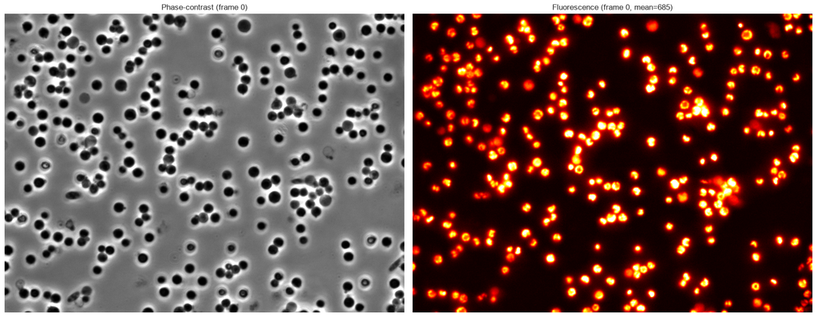

## 8. Fluorescence Quantification and Dynamics

Measures fluorescence intensity and distribution metrics within each phase-contrast cell mask. Metrics per cell per frame:

| Metric | Description |
| --- | --- |
| mean/total/min/max intensity | Basic intensity statistics |
| CV (std/mean) | Nucleoid heterogeneity — high = concentrated, low = dispersed |
| nNRM (KS statistic) | Non-normality of pixel distribution (Gough et al. 2014) |
| skewness, kurtosis | Distribution shape descriptors |

```
Fluorescence measurements: 4993 rows
Matched 4960/4960 detections (100.0%) with fluorescence
Median fluorescence intensity per track: 2035
Median CV per track: 0.466
Median nNRM per track: 0.097
```

```
Nucleoid distribution: 4960/4960 cell-frames measured
```

### 8.1 Population mean fluorescence per frame

[interactive chart not shown]

```
Frame 0 mean fluorescence: 2750
Frame 30 mean fluorescence: 1967
Change: 0.72x
```

*Source: `tracked_cells.csv`*

### 8.2 Relative fluorescence F(t)/F(0)

Same frame-0 cohort used for swelling analysis. Shows how fluorescence changes relative to each cell's initial value. Disappeared vs survived split reveals whether fluorescence predicts cell fate.

[interactive chart not shown]

```
Final F(t)/F(0): 0.770 +/- 0.042
Cells contributing at final frame: 40
```

*Source: `tracked_cells.csv`*

### 8.2b Relative fluorescence F(t)/F(0) vs. normalized lifespan, by fate

Companion to §6.5b — same three panels for fluorescence.

[interactive chart not shown]

```
F(t)/F(0) at frame 0: 1.000
F(t)/F(0) at frame 30: 0.758
```

*Sources: `tracked_cells.csv`, `track_statistics.csv`*

### 8.3 Fluorescence vs. swelling correlation

Does fluorescence intensity track with cell volume? Each point is one cell at one frame. A positive correlation suggests fluorescence scales with cell size (membrane or cytoplasmic stain); no correlation suggests a localized signal (e.g., nuclear).

[interactive chart not shown]

*Source: `tracked_cells.csv`*

### 8.4 Nucleoid heterogeneity: CV dynamics

CV (coefficient of variation = std/mean of pixel intensities within each cell mask) measures nucleoid spatial concentration. High CV = bright nucleoid spots on dark cytoplasmic background (intact, concentrated). Low CV = more uniform distribution (dispersed nucleoid).

Three views: absolute per frame, lifespan-normalized (all tracks aligned to [0,1]), and disappeared vs survived.

[interactive chart not shown]

```
CV at frame 0: 0.486
CV at frame 30: 0.419
```

*Sources: `tracked_cells.csv`, `track_statistics.csv`*

### 8.4c Nucleoid edge-distance dynamics

[interactive chart not shown]

```
Edge-dist / (R/3) at frame 0: 1.544
Edge-dist / (R/3) at frame 30: 1.542
```

*Sources: `tracked_cells.csv`, `track_statistics.csv`*

### 8.5 Non-Normality Index (nNRM) dynamics

nNRM = Kolmogorov-Smirnov statistic comparing pixel intensity distribution against a Gaussian with matching mean and std (Gough et al. 2014, PLOS ONE). Range [0, 1]: 0 = Gaussian, 1 = maximally non-Gaussian. Complements CV — CV measures spread, nNRM measures distribution shape. A high nNRM indicates distinct subpopulations within the cell mask (bright nucleoid vs dark cytoplasm).

[interactive chart not shown]

```
nNRM at frame 0: 0.095
nNRM at frame 30: 0.087
```

*Sources: `tracked_cells.csv`, `track_statistics.csv`*

### 8.5b Nucleoid spatial σ dynamics

σ of the 2D intensity-weighted spatial distribution of suprathreshold pixels (mean of eigenvalues of the weighted covariance), normalized by the cell's pixel-space R. Captures dispersion: small σ ⇒ tight cluster; large σ ⇒ spread across the cell.

[interactive chart not shown]

```
σ / R at frame 0: 0.339
σ / R at frame 30: 0.350
```

*Sources: `tracked_cells.csv`, `track_statistics.csv`*

### 8.5c Peri/core asymmetry dynamics

Signed asymmetry index `(I_peri − I_core) / (I_peri + I_core)` where the two regions are set by `PERI_CORE_RINGS = (core_max, peri_min, peri_max)` as fractions of the cell's equivalent radius R. Default `(0.15, 0.35, 0.55)` — narrow core samples the donut center dip, peri brackets the donut peak zone identified from real radial profiles (see `docs/peri_core_asymmetry_definition_history.md` for the sweep and the historical parameter sets). The intermediate band and the outer rim are ignored. Bounded in [−1, 1]:

- **positive** → edge-clustered (expanded / donut-shaped nucleoid),
- **negative** → center-clustered (compacted nucleoid),
- **0** → radially uniform.

Areas are unequal, so mean rather than total intensity is used in each ring. Uses raw (unthresholded) intensities so the metric is defined even for near-uniform cells. Complements §8.4c (edge distance) and §8.5b (σ) — same three-panel layout by fate.

[interactive chart not shown]

```
Peri/core asymmetry at frame 0: -0.043
Peri/core asymmetry at frame 30: -0.052
```

*Sources: `tracked_cells.csv`, `track_statistics.csv`*

### 8.5d Peri/core asymmetry aligned to phase disappearance

Per-cell trajectory of `peri_core_asymmetry` in the window [-`FLUOR_ALIGN_WINDOW`, 0] frames before each disappeared cell's last detection. Complements §8.5c by removing the averaging-across-frames artifact: cells caught at absolute frame N are at different stages of their own life cycle, so a per-frame median smears the trajectory. Aligning by offset from last-detected frame puts every cell on the same timeline relative to burst.

- **Left panel**: individual trajectories (thin blue), median + IQR band across cells. Shows whether initial donut/sparse phenotypes converge to a common pre-burst state.
- **Right panel**: baseline (offset -N) vs. last-frame (offset 0) scatter, one dot per cell. Points off the diagonal indicate a transformation between initial and pre-burst states.

[interactive chart not shown]

```
Aligned 196 disappeared tracks (window=-3..0)
  offset -3: median asymmetry = -0.064
  offset -2: median asymmetry = -0.066
  offset -1: median asymmetry = -0.072
  offset +0: median asymmetry = -0.069
```

*Source: `peri_core_alignment.csv`*

### 8.6 Fluorescence dynamics around phase disappearance

Fluorescence loss is rarely instantaneous and rarely aligned with the phase mask vanishing — DNA exits through membrane pores more slowly than proteins, and the lysis itself can take multiple frames. To make this visible, for each `disappeared` cell we align its mean intensity to its last phase-detection frame and plot the ±`FLUOR_ALIGN_WINDOW` frames around that anchor.

Post-disappearance frames (offset > 0) use the cell's **final phase mask** to integrate fluorescence — the cell's last known ROI applied to subsequent fluorescence frames.

[interactive chart not shown]

```
Aligned 196 disappeared tracks (window=+/-3)
  offset -3: median F_norm = 1.000
  offset -2: median F_norm = 0.961
  offset -1: median F_norm = 0.901
  offset +0: median F_norm = 0.841
  offset +1: median F_norm = 0.218
  offset +2: median F_norm = 0.140
  offset +3: median F_norm = 0.116
```

*Source: `fluorescence_alignment.csv`*

### 8.9 Fluorescence concentration (dilution-corrected)

Raw fluorescence intensity confounds true signal changes with dilution from cell swelling — a cell that doubles in volume halves its concentration even if total fluorophore content stays constant. Fluorescence concentration (`total_intensity / volume`) corrects for this, revealing whether fluorescence changes are biological or geometric.

```
Fluorescence concentration: 4960/4960 cells computed
```

[interactive chart not shown]

```
Frame 0 mean concentration: 450954.627
Frame 30 mean concentration: 261399.030
Change: 0.58x
```

*Source: `tracked_cells.csv`*

### 8.11 Surface-area-to-volume ratio

SA:V ratio is a proxy for membrane mechanical stress. As cells swell (volume increases faster than surface area for a sphere), SA:V decreases — the membrane must stretch to accommodate the growing volume. Lower SA:V may indicate cells closer to their mechanical rupture threshold.

```
SA:V ratio: 4960/4960 cells computed
Median SA:V at frame 0: 2.6860
```

[interactive chart not shown]

```
SA:V at frame 0: 2.7343
SA:V at frame 30: 2.2234
Median SA:V at death: 2.2985
Median SA:V at end (survived): 2.1870
```

*Sources: `tracked_cells.csv`, `track_statistics.csv`*

### 8.13 Pre-burst fluorescence behavior

Does fluorescence change in the frames immediately before a cell disappears? For each disappeared track, fits a linear trend to mean fluorescence intensity in a 5-frame window before the last detection. A positive slope with intensity exceeding baseline indicates a pre-burst "spike" — possible membrane permeabilization allowing dye influx before final rupture.

```
Pre-burst fluorescence (5-frame window):
  Tracks with pre-burst spike: 18/210 (9%)
```

[interactive chart not shown]

```
Median pre-burst slope: -71.14
Cells with pre-burst spike: 18/210
```

*Sources: `tracked_cells.csv`, `track_statistics.csv`*

### 8.14 Cell fate prediction from frame-0 features

Can we predict which cells will die just from their appearance at frame 0? Two complementary tests on the **frame-0 cohort** (cells visible at `frame == 0`, labelled by their eventual `disappeared` flag from `track_statistics.csv`):

The Mann-Whitney table tests each feature in isolation; the logistic regression asks whether the five together can rank cells by death probability (ROC curve + feature importance).

**Related views of the same question, elsewhere in the report:**

- §8.17 Initial fluorescence features vs. lifespan — same frame-0 features, but plotted against the *continuous* lifetime variable with Spearman rho. Mann-Whitney here, Spearman there.
- §6.5 Swelling extent vs. initial cell size and survival — initial volume vs. eventual fate (V(0) split by survived/disappeared).

```
Frame-0 features by fate (Mann-Whitney U, two-sided):
  Cohort: 40 survived, 184 died
   area: median 4.152 (surv) vs 3.784 (died) [↓ died], U=2837, p=2.33e-02
     cv: median 0.464 (surv) vs 0.489 (died) [↑ died], U=4139, p=2.17e-01
   nnrm: median 0.086 (surv) vs 0.094 (died) [↑ died], U=4005, p=3.82e-01
  mean_edge_distance_norm: median 1.559 (surv) vs 1.565 (died) [↑ died], U=3848, p=6.52e-01
  gaussian_sigma_norm: median 0.346 (surv) vs 0.337 (died) [↓ died], U=2998, p=6.66e-02
```

|  | feature | n_survived | n_died | median_survived | median_died | U | p_value |
| --- | --- | --- | --- | --- | --- | --- | --- |
| 0 | area | 40 | 184 | 4.151929 | 3.783747 | 2837.0 | 0.023332 |
| 1 | cv | 40 | 184 | 0.464348 | 0.489447 | 4139.0 | 0.217113 |
| 2 | nnrm | 40 | 184 | 0.085868 | 0.093558 | 4005.0 | 0.382377 |
| 3 | mean_edge_distance_norm | 40 | 184 | 1.559363 | 1.564869 | 3848.0 | 0.652065 |
| 4 | gaussian_sigma_norm | 40 | 184 | 0.346120 | 0.337368 | 2998.0 | 0.066574 |

```
Fate prediction (LOO cross-validation, n=224):
  AUC: 0.537
  Accuracy: 81.7%
  Died: 184, Survived: 40
  Feature importance (z-scored coefficients):
    area: -0.309 (↓ death)
    cv: +0.180 (↑ death)
    nnrm: -0.151 (↓ death)
    mean_edge_distance_norm: -0.060 (↓ death)
    gaussian_sigma_norm: -0.241 (↓ death)
  Per-class performance (probability threshold 0.5):
    survived     (n= 40): precision=0.000, recall=0.000, f1=0.000
    disappeared  (n=184): precision=0.821, recall=0.995, f1=0.899
  Confusion matrix (rows = actual, cols = predicted):
                              pred: survived  pred: disappeared
    actual: survived                0            40
    actual: disappeared             1           183
Fate prediction (LOO cross-validation, n=224):
  AUC: 0.492
  Accuracy: 81.7%
  Died: 184, Survived: 40
  Feature importance (z-scored coefficients):
    cv: +0.037 (↑ death)
    nnrm: -0.121 (↓ death)
    mean_edge_distance_norm: -0.164 (↓ death)
    gaussian_sigma_norm: -0.424 (↓ death)
  Per-class performance (probability threshold 0.5):
    survived     (n= 40): precision=0.000, recall=0.000, f1=0.000
    disappeared  (n=184): precision=0.821, recall=0.995, f1=0.899
  Confusion matrix (rows = actual, cols = predicted):
                              pred: survived  pred: disappeared
    actual: survived                0            40
    actual: disappeared             1           183
```

[interactive chart not shown]

*Sources: `fate_predictions.csv`, `fate_prediction_summary.csv`*

```
Feature-set comparison:
                        full (5)   no-area (4)
  AUC                   0.537      0.492
  Accuracy              0.817      0.817
  Recall (survived)     0.000      0.000
  Recall (disappeared)  0.995      0.995
  F1 (survived)         0.000      0.000
  F1 (disappeared)      0.899      0.899
  (differences small; full feature set remains the default)
```

### 8.16 Nucleus persistence after cell lysis

Do fluorescent nuclei (DNA) survive as discrete objects after the cell membrane ruptures? To test this, we independently segment the fluorescence channel with Cellpose and compare object counts frame-by-frame against phase-contrast cells.

If nuclei persist after lysis, fluorescence counts should decline slower than phase counts (growing offset). If they disperse immediately, both should decline in parallel (constant offset).

```
  Frame  0: 288 nuclei
```

```
  Frame  1: 274 nuclei
```

```
  Frame  2: 271 nuclei
```

```
  Frame  3: 275 nuclei
```

```
  Frame  4: 264 nuclei
```

```
  Frame  5: 269 nuclei
```

```
  Frame  6: 258 nuclei
```

```
  Frame  7: 257 nuclei
```

```
  Frame  8: 246 nuclei
```

```
  Frame  9: 257 nuclei
```

```
  Frame 10: 247 nuclei
```

```
  Frame 11: 247 nuclei
```

```
  Frame 12: 224 nuclei
```

```
  Frame 13: 228 nuclei
```

```
  Frame 14: 213 nuclei
```

```
  Frame 15: 204 nuclei
```

```
  Frame 16: 185 nuclei
```

```
  Frame 17: 193 nuclei
```

```
  Frame 18: 177 nuclei
```

```
  Frame 19: 168 nuclei
```

```
  Frame 20: 152 nuclei
```

```
  Frame 21: 140 nuclei
```

```
  Frame 22: 130 nuclei
```

```
  Frame 23: 123 nuclei
```

```
  Frame 24: 106 nuclei
```

```
  Frame 25: 115 nuclei
```

```
  Frame 26: 113 nuclei
```

```
  Frame 27: 110 nuclei
```

```
  Frame 28: 111 nuclei
```

```
  Frame 29: 100 nuclei
```

```
  Frame 30: 95 nuclei
```

```
Phase cells lost (first to last frame): 198
Fluor nuclei lost (first to last frame): 193
Difference std across frames: 7.7

Conclusion: Phase cells and fluorescent nuclei disappear at the same rate. DNA signal does NOT persist as a discrete object after cell lysis — the fluorescent material disperses upon membrane rupture.
```

[interactive chart not shown]

```
Phase vs fluor count: Pearson r = 0.995, p = 6.42e-31
```

*Sources: `nucleus_persistence.csv`, `nucleus_persistence_summary.csv`*

### 8.17 Initial fluorescence features vs. lifespan

Implementation: `plot_initial_features_vs_lifespan()` in `src/cell_analysis/plotting.py`.

[interactive chart not shown]

```
Initial fluorescence vs lifetime: Spearman rho = -0.086, p = 2.00e-01
Initial CV vs lifetime: Spearman rho = -0.105, p = 1.16e-01
Initial nNRM vs lifetime: Spearman rho = -0.181, p = 6.47e-03
```

*Sources: `tracked_cells.csv`, `track_statistics.csv`*

## 9. Export Results

Each CSV is saved inline by the cell that produces it, so the source link under each plot resolves at the moment the plot is rendered. The cell below lists every CSV currently on disk.

[output not shown]

```
Saved 16 files to results/control_experiment/
  clustering_summary.csv
  fate_prediction_summary.csv
  fate_prediction_summary_no_area.csv
  fate_predictions.csv
  fate_predictions_no_area.csv
  fluorescence_alignment.csv
  frame0_fate_comparison.csv
  frame_diagnostics.csv
  merge_log.csv
  nucleus_persistence.csv
  nucleus_persistence_summary.csv
  peri_core_alignment.csv
  spatial_gradient.csv
  spatial_gradient_summary.csv
  track_statistics.csv
  tracked_cells.csv
```

## 10. Export HTML Report

Saves the notebook to disk and exports a self-contained HTML copy to `results/<RUN_NAME>/report.html`. Set `EXPORT_HTML = False` (top of notebook) to skip. The CLI runner (`scripts/run_experiment.py`) uses the same exporter, so interactive and CLI reports stay in sync.